# hw10-ghosh17

NetID: ghosh17

Subhankar Ghosh

# Question 1

```r
library(ISLR)
library(caret)
library(sparcl)
uin = 657853292
set.seed(uin)
```

```r
oj_idx = createDataPartition(OJ$Purchase, p = 0.5, list = FALSE)
oj_trn = OJ[oj_idx,]
oj_tst = OJ[-oj_idx,]
```

```r
lin_grid = expand.grid(C = c(2 ^ (-5:5)))
cv_5 = trainControl(method = "cv", number = 5)
```

```r
calc_acc = function(actual, predicted) {
  mean(actual == predicted)
}
```

## a

```r
set.seed(uin)
svm_mdl <- train(
  Purchase ~ .,
  data = oj_trn,
  method = "svmLinear",
  trControl = cv_5,
  tuneGrid = lin_grid)
```

```r
svm_best <- svm_mdl$bestTune
svm_mdl_tst <- calc_acc(actual = oj_tst$Purchase, predicted = predict(svm_mdl, oj_tst))
result <- cbind(best_tune = svm_best, test_accuracy = svm_mdl_tst)
row.names(result) <- NULL
colnames(result) = c("Best Tune", "Test accuracy")
knitr::kable(result, align = "c")
```

| Best Tune | Test accuracy |
| --- | --- |
| 0.0625 | 0.8258427 |

**best tuning parameter: C=0.0625, test accuracy:0.8258**

## b

```r
set.seed(uin)
svm_poly_mdl <- train(
  Purchase ~ .,
  data = oj_trn,
  method = "svmPoly",
  trControl = cv_5)

svm_poly_best <- svm_poly_mdl$bestTune
svm_poly_tst <- calc_acc(actual = oj_tst$Purchase, predicted = predict(svm_poly_mdl, oj_tst))
result_2 <- cbind.data.frame(svm_poly_best, test_accuracy = svm_poly_tst)
row.names(result_2) <- NULL
knitr::kable(result_2, align = "c")
```

| degree | scale | C | test_accuracy |
| --- | --- | --- | --- |
| 3 | 0.01 | 0.5 | 0.829588 |

**best tuning parameter: degree=3, scale=0.01, C=0.5, test accuracy:0.8295**

## c

```r
radial_tune_grid = expand.grid(C = c(2 ^ (-2:3)), sigma  = c(2 ^ (-3:1)))
set.seed(uin)
svm_radial_mdl <- train(
  Purchase ~ .,
  data = oj_trn,
  method = "svmRadial",
  trControl = cv_5,
  tuneGrid = radial_tune_grid)

svm_rad_best <- svm_radial_mdl$bestTune
svm_radial_tst <- calc_acc(actual = oj_tst$Purchase, predicted = predict(svm_radial_mdl, oj_tst))
result_3 <- cbind.data.frame(svm_rad_best,test_accuracy = svm_radial_tst)
row.names(result_3) <- NULL

knitr::kable(result_3, aling = "c")
```

| sigma | C | test_accuracy |
| --- | --- | --- |
| 2 | 1 | 0.7790262 |

**best tuning parameter: sigma=2, C=1, test accuracy:0.7790**

## d

```r
set.seed(uin)
rf_mdl <- train(
  Purchase ~ .,
  data = oj_trn,
  method = "rf",
  trControl = cv_5)

rf_best <- rf_mdl$bestTune
rf_tst <- calc_acc(actual = oj_tst$Purchase, predicted = predict(rf_mdl,oj_tst))
result_4 <- cbind.data.frame(rf_best, test_accuracy = rf_tst)
row.names(result_4) <- NULL
knitr::kable(result_4, align = "c")
```

| mtry | test_accuracy |
| --- | --- |
| 9 | 0.8071161 |

**best tuning parameter: mtry=9, test accuracy:0.8071**

## e

```r
result_5 <- cbind(Model = c("Linear SVM", "Polynomial SVM", "Radial SVM", "Random Forest"),
                  Test_Accuracy = c(svm_mdl_tst, svm_poly_tst, svm_radial_tst, rf_tst))
knitr::kable(result_5, align = "c")
```

| Model | Test_Accuracy |
| --- | --- |
| Linear SVM | 0.825842696629214 |
| Polynomial SVM | 0.829588014981273 |
| Radial SVM | 0.779026217228464 |
| Random Forest | 0.807116104868914 |

**svm with polynomial kernel function performs the best**

# Question 2

```r
set.seed(uin)
clust_data = read.csv("clust_data.csv")
```

```r
withinss = rep(0, 15)
for(k in 1:15)
{
  km = kmeans(x = clust_data, centers = k, nstart = 10)
  withinss[k] = km$tot.withinss
}
```

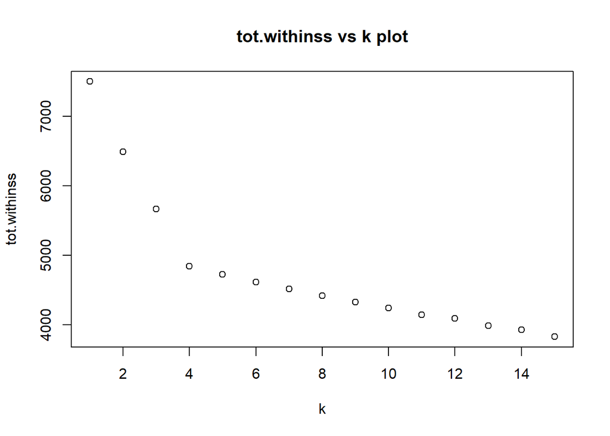

```r
plot(1:15, withinss, xlab = "k", ylab = "tot.withinss", main = "tot.withinss vs k plot")
```

We can see the plot “elbows” at k = 4, So I think the data should have 4 clusters.

## b

```r
km_best = kmeans(x = clust_data, centers = 4, nstart = 10)
table(km_best$cluster)
```

```
##
##  1  2  3  4
## 25 25 25 25
```

From the above result we can see that 25 observations are in each of the clusters.

```r
km_best$tot.withinss
```

```
## [1] 4844.926
```

The total within cluster variation is **4844.926**

## c

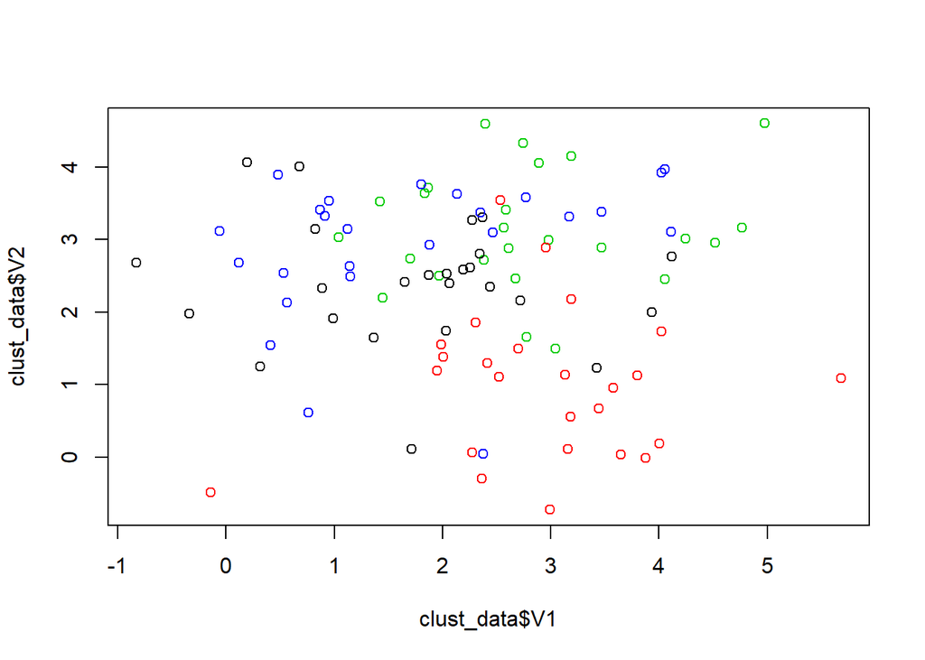

```r
plot(clust_data$V1, clust_data$V2, col = km_best$cluster)
```

From the above plot I do not think I made a good decision in using just 4 clusters. The rationale behind it is that the points in the 4 clusters seem intermingled and not exacly separated into four clusters that look separated to the naked eye.

## d

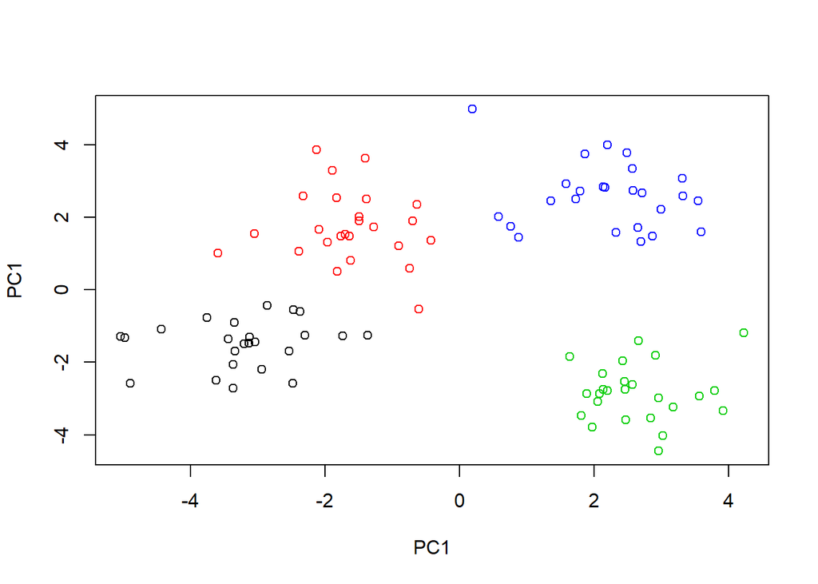

```r
pca.clust = prcomp(clust_data, scale = TRUE)
pca.comp = as.data.frame(pca.clust$x)
plot(pca.comp$PC1, pca.comp$PC2, col = km_best$cluster, xlab = "PC1", ylab = "PC1")
```

Looking at the above plot it totally makes sense to choose 4 clusters. Since now the clusters look separate from each other to the naked eye. I believe this happens because in the plot where we had used just the first two dimensions of the dataset we did not look at the data from the perspective of the other dimensions but when we applied PCA and used just the first two components it gives us a view taking into account all the dimensions.

## e

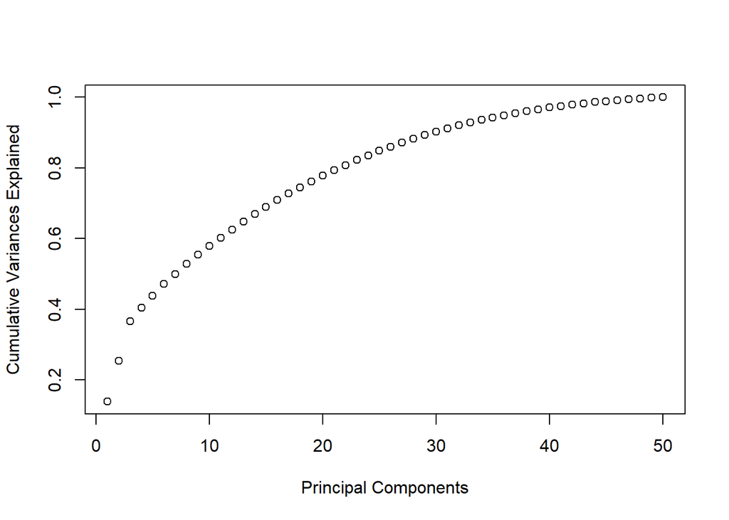

```r
variances <- pca.clust$sdev^2
cumulative.var = cumsum(variances) / sum(variances)
plot(1:50, cumulative.var, xlab = "Principal Components", ylab = "Cumulative Variances Explained")
```

```r
sum(cumulative.var <= 0.95)
```

```
## [1] 36
```

# Question 3

## a

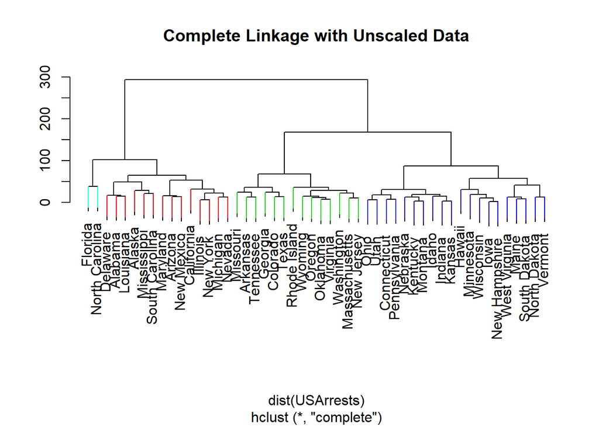

```r
cp_us = hclust(dist(USArrests), method = "complete")
cut_cp_us = cutree(cp_us , 4)
ColorDendrogram(cp_us, y = cut_cp_us,
                labels = names(cut_cp_us),
                main = "Complete Linkage with Unscaled Data",
                branchlength = 50)
```

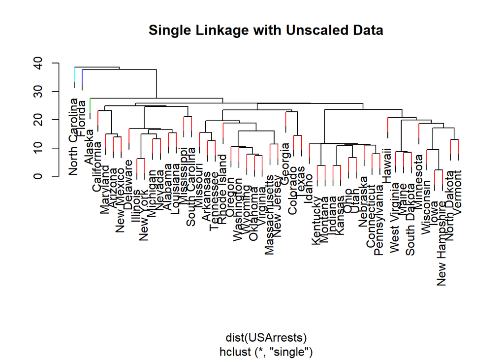

```r
sn_us = hclust(dist(USArrests), method = "single")
cut_sn_us = cutree(sn_us , 4)
ColorDendrogram(sn_us, y = cut_sn_us,
                labels = names(cut_sn_us),
                main = "Single Linkage with Unscaled Data",
                branchlength = 5)
```

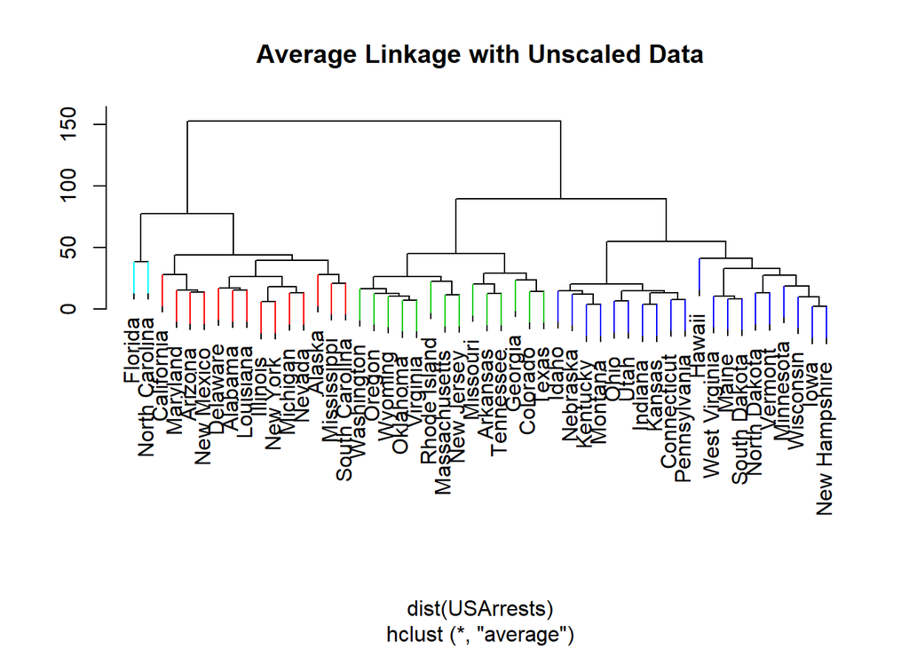

```r
av_us = hclust(dist(USArrests), method = "average")
cut_av_us = cutree(av_us , 4)
ColorDendrogram(av_us, y = cut_av_us,
                labels = names(cut_av_us),
                main = "Average Linkage with Unscaled Data",
                branchlength = 25)
```

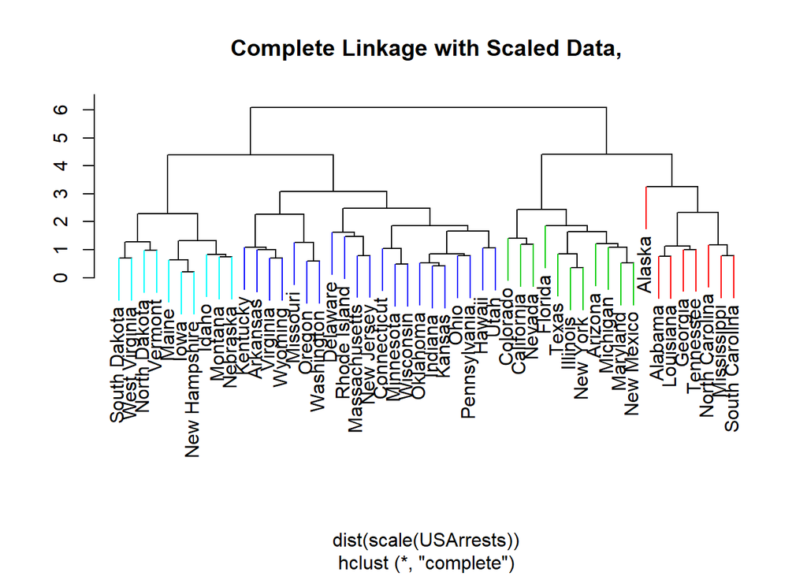

```r
cp = hclust(dist(scale(USArrests)), method = "complete")
cut_cp = cutree(cp , 4)
ColorDendrogram(cp, y = cut_cp,
                labels = names(cut_cp),
                main = "Complete Linkage with Scaled Data,",
                branchlength = 1.5)
```

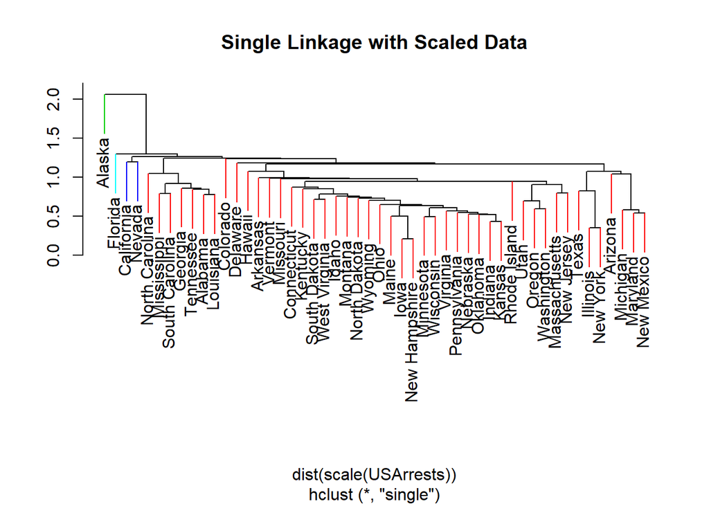

```r
sn = hclust(dist(scale(USArrests)), method = "single")
cut_sn = cutree(sn , 4)
ColorDendrogram(sn, y = cut_sn,
                labels = names(cut_sn),
                main = "Single Linkage with Scaled Data",
                branchlength = 0.5)
```

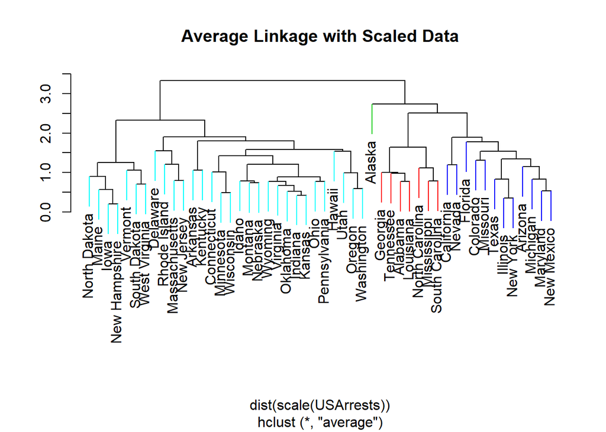

```r
av = hclust(dist(scale(USArrests)), method = "average")
cut_av = cutree(av , 4)
ColorDendrogram(av, y = cut_av,
                labels = names(cut_av),
                main = "Average Linkage with Scaled Data",
                branchlength = 0.75)
```

## b

**Scaled data with Complete Linkage performs the best as the clusters seem to have similar number of elements in each of them**

## c

**Let us try the centroid linkage with and without scaling**

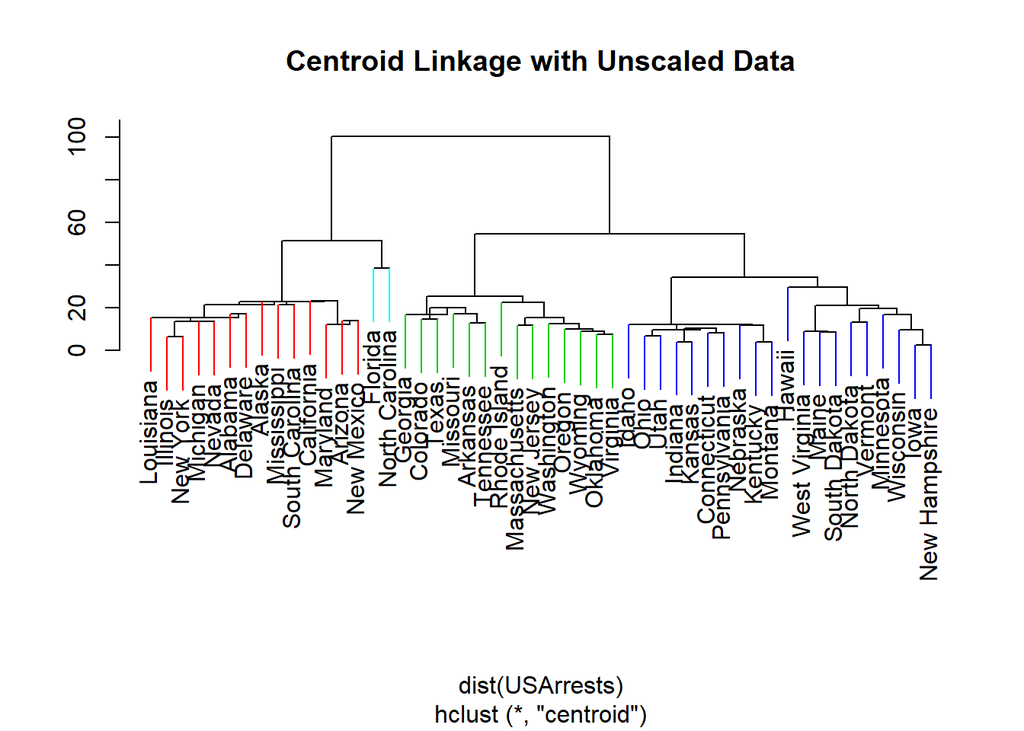

```r
cd_us = hclust(dist(USArrests), method = "centroid")
cut_cd_us = cutree(cd_us , 4)
ColorDendrogram(cd_us, y = cut_cd_us,
                labels = names(cut_cd_us),
                main = "Centroid Linkage with Unscaled Data",
                branchlength = 25)
```

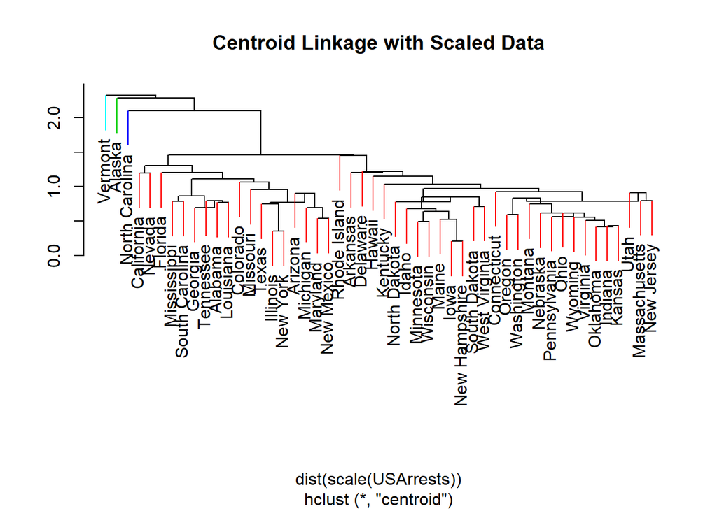

```r
cd = hclust(dist(scale(USArrests)), method = "centroid")
cut_cd = cutree(cd , 4)
ColorDendrogram(cd, y = cut_cd,
                labels = names(cut_cd),
                main = "Centroid Linkage with Scaled Data",
                branchlength = 0.5)
```

**Yes the results from (b) and the one with the centroid linkage are different. The scaled and complete linkage clustering gives rise to clusters having almost similar number of elements in each of the clusters but the one with centroid linkage do not have that property.**

## d

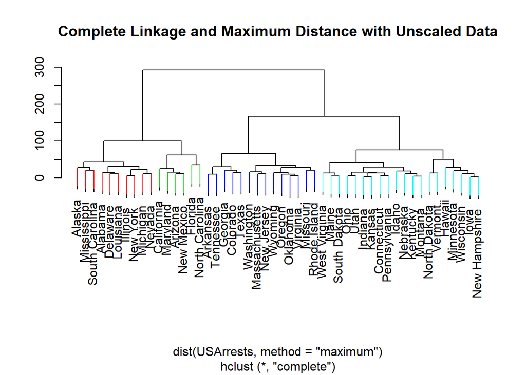

```r
cp_max_us = hclust(dist(USArrests,method = "maximum"), method = "complete")
cut_cp_max_us = cutree(cp_max_us , 4)
ColorDendrogram(cp_max_us, y = cut_cp_max_us,
                labels = names(cut_cp_max_us),
                main = "Complete Linkage and Maximum Distance with Unscaled Data",
                branchlength = 50)
```

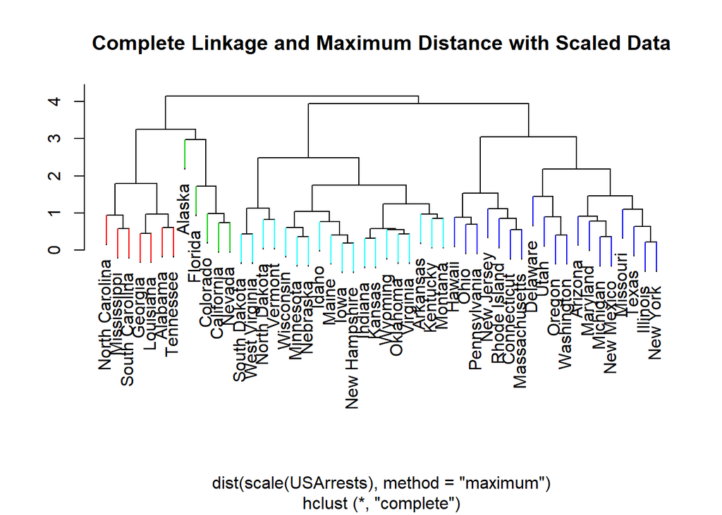

```r
cp_max = hclust(dist(scale(USArrests),method = "maximum"), method = "complete")
cut_cp_max = cutree(cp_max , 4)
ColorDendrogram(cp_max, y = cut_cp_max,
                labels = names(cut_cp_max),
                main = "Complete Linkage and Maximum Distance with Scaled Data",
                branchlength = 0.75)
```

**Yes we obtain defferent results from (b) and the Maximum distance clustering**